# 0. Setup - API Key, Load [R] Packages

### Hurdle: Immediate Matrix without Header (Variable Names)

BUT, It IS there in row 1. EVERYTHING is currently read as ‘character’ strings of text stored in a tabular MATRIX

I view character strings as a huge benefit. Keeping everything as characters (at least initially) allows for consistent behavior when you merge, filter, apply logic to your data. It Prevents you from shooting yourself in the foot (like adding two strings, say “State Code” + “County Code”). This is Tomatoe = Potatoe. Later on, we explicitly convert intended numeric numbers into numeric data (Tomatoe = Tomatoe).

```r
class(data_pdb_raw)
```

```
## [1] "matrix"
```

```r
dim(data_pdb_raw)
```

```
## [1] 2347    8
```

```r
str(data_pdb_raw)
```

```
##  chr [1:2347, 1:8] "County_name" "Los Angeles County" ...
```

```r
colnames(data_pdb_raw)
```

```r
rownames(data_pdb_raw)
```

### Hurdle: Humans recognize that first row represents variable names, Need Computer to recognize it too (as column names)

```r
# first row of matrix - humans understand as the intended variable names
data_pdb_raw[1,]
```

```
## [1] "County_name"             "State_name"
## [3] "Tot_Population_CEN_2010" "LAND_AREA"
## [5] "Females_CEN_2010"        "state"
## [7] "county"                  "tract"
```

```r
# column names (header) of matrix - computer understands as empty
colnames(data_pdb_raw)
```

```r
# make the assignment: column names of matrix = first row of matrix
colnames(data_pdb_raw) = data_pdb_raw[1,]

# assignment reflected but first row still present (redundant)
data_pdb_raw %>% head()
```

```
##      County_name          State_name   Tot_Population_CEN_2010
## [1,] "County_name"        "State_name" "Tot_Population_CEN_2010"
## [2,] "Los Angeles County" "California" "4731"
## [3,] "Los Angeles County" "California" "3664"
## [4,] "Los Angeles County" "California" "5990"
## [5,] "Los Angeles County" "California" "3363"
## [6,] "Los Angeles County" "California" "4199"
##      LAND_AREA   Females_CEN_2010   state   county   tract
## [1,] "LAND_AREA" "Females_CEN_2010" "state" "county" "tract"
## [2,] "0.442"     "2352"             "06"    "037"    "101110"
## [3,] "1.021"     "1869"             "06"    "037"    "101122"
## [4,] "0.251"     "2953"             "06"    "037"    "101210"
## [5,] "0.27"      "1702"             "06"    "037"    "101220"
## [6,] "0.996"     "2183"             "06"    "037"    "101300"
```

```r
# data_pdb_mat: a new object distinguishing it from _raw source
# throw away first row

data_pdb_mat = data_pdb_raw[-1,]

head(data_pdb_mat)
```

```
##      County_name          State_name   Tot_Population_CEN_2010 LAND_AREA
## [1,] "Los Angeles County" "California" "4731"                  "0.442"
## [2,] "Los Angeles County" "California" "3664"                  "1.021"
## [3,] "Los Angeles County" "California" "5990"                  "0.251"
## [4,] "Los Angeles County" "California" "3363"                  "0.27"
## [5,] "Los Angeles County" "California" "4199"                  "0.996"
## [6,] "Los Angeles County" "California" "3903"                  "2.436"
##      Females_CEN_2010 state county tract
## [1,] "2352"           "06"  "037"  "101110"
## [2,] "1869"           "06"  "037"  "101122"
## [3,] "2953"           "06"  "037"  "101210"
## [4,] "1702"           "06"  "037"  "101220"
## [5,] "2183"           "06"  "037"  "101300"
## [6,] "1948"           "06"  "037"  "101400"
```

### Hurdle: Matrix to Dataframe, but [R] default converts characters, we want to keep everything as Fundamental ‘Character’ string

```r
# set options
```

```r
str(data_pdb_mat)
```

```
##  chr [1:2346, 1:8] "Los Angeles County" "Los Angeles County" ...
##  - attr(*, "dimnames")=List of 2
##   ..$ : NULL
##   ..$ : chr [1:8] "County_name" "State_name" "Tot_Population_CEN_2010" "LAND_AREA" ...
```

```r
# NOTE: default of [R]: automaticaly converting 'character' to 'factor'
# this is an artifact leftover from oldtime convenience

data_pdb_mat %>% as.data.frame() %>% str()
```

```
## 'data.frame':    2346 obs. of  8 variables:
##  $ County_name            : Factor w/ 1 level "Los Angeles County": 1 1 1 1 1 1 1 1 1 1 ...
##  $ State_name             : Factor w/ 1 level "California": 1 1 1 1 1 1 1 1 1 1 ...
##  $ Tot_Population_CEN_2010: Factor w/ 1888 levels "0","1","1029",..: 1206 709 1626 557 969 819 56 704 54 791 ...
##  $ LAND_AREA              : Factor w/ 1078 levels "0","0.027","0.031",..: 374 755 188 207 740 964 389 540 131 1045 ...
##  $ Females_CEN_2010       : Factor w/ 1572 levels "0","1","101",..: 863 527 1196 404 747 577 1547 546 1542 653 ...
##  $ state                  : Factor w/ 1 level "06": 1 1 1 1 1 1 1 1 1 1 ...
##  $ county                 : Factor w/ 1 level "037": 1 1 1 1 1 1 1 1 1 1 ...
##  $ tract                  : Factor w/ 2346 levels "101110","101122",..: 1 2 3 4 5 6 7 8 9 10 ...
```

```r
# turn that default option OFF
options(stringsAsFactors = FALSE)

data_pdb_mat %>% as.data.frame() %>% str()
```

```
## 'data.frame':    2346 obs. of  8 variables:
##  $ County_name            : chr  "Los Angeles County" "Los Angeles County" "Los Angeles County" "Los Angeles County" ...
##  $ State_name             : chr  "California" "California" "California" "California" ...
##  $ Tot_Population_CEN_2010: chr  "4731" "3664" "5990" "3363" ...
##  $ LAND_AREA              : chr  "0.442" "1.021" "0.251" "0.27" ...
##  $ Females_CEN_2010       : chr  "2352" "1869" "2953" "1702" ...
##  $ state                  : chr  "06" "06" "06" "06" ...
##  $ county                 : chr  "037" "037" "037" "037" ...
##  $ tract                  : chr  "101110" "101122" "101210" "101220" ...
```

```r
# store as data frame
data_pdb_df = data_pdb_mat %>% as.data.frame()
```

### Hurdle: Humans recognize that ‘Tot_Population_CEN_2010’ represents a count, Need Computer to recognize it too (as ‘Numeric’ number)

```r
data_pdb_df %>% str()
```

```
## 'data.frame':    2346 obs. of  8 variables:
##  $ County_name            : chr  "Los Angeles County" "Los Angeles County" "Los Angeles County" "Los Angeles County" ...
##  $ State_name             : chr  "California" "California" "California" "California" ...
##  $ Tot_Population_CEN_2010: chr  "4731" "3664" "5990" "3363" ...
##  $ LAND_AREA              : chr  "0.442" "1.021" "0.251" "0.27" ...
##  $ Females_CEN_2010       : chr  "2352" "1869" "2953" "1702" ...
##  $ state                  : chr  "06" "06" "06" "06" ...
##  $ county                 : chr  "037" "037" "037" "037" ...
##  $ tract                  : chr  "101110" "101122" "101210" "101220" ...
```

```r
# want numeric numbers for
# Tot_Population_CEN_2010
# LAND_AREA
# Females_CEN_2010

# more data
data_pdb_df = data_pdb_df %>%
mutate(Tot_Population_CEN_2010=as.numeric(Tot_Population_CEN_2010),
       LAND_AREA=as.numeric(LAND_AREA)
      )

data_pdb_df %>%
str()
```

```
## 'data.frame':    2346 obs. of  8 variables:
##  $ County_name            : chr  "Los Angeles County" "Los Angeles County" "Los Angeles County" "Los Angeles County" ...
##  $ State_name             : chr  "California" "California" "California" "California" ...
##  $ Tot_Population_CEN_2010: num  4731 3664 5990 3363 4199 ...
##  $ LAND_AREA              : num  0.442 1.021 0.251 0.27 0.996 ...
##  $ Females_CEN_2010       : chr  "2352" "1869" "2953" "1702" ...
##  $ state                  : chr  "06" "06" "06" "06" ...
##  $ county                 : chr  "037" "037" "037" "037" ...
##  $ tract                  : chr  "101110" "101122" "101210" "101220" ...
```

```r
data_pdb_df %>%
summary()
```

```
##  County_name         State_name        Tot_Population_CEN_2010
##  Length:2346        Length:2346        Min.   :    0
##  Class :character   Class :character   1st Qu.: 3203
##  Mode  :character   Mode  :character   Median : 4098
##                                        Mean   : 4185
##                                        3rd Qu.: 5162
##                                        Max.   :12544
##    LAND_AREA       Females_CEN_2010      state
##  Min.   :  0.000   Length:2346        Length:2346
##  1st Qu.:  0.229   Class :character   Class :character
##  Median :  0.392   Mode  :character   Mode  :character
##  Mean   :  1.730
##  3rd Qu.:  0.702
##  Max.   :397.252
##     county             tract
##  Length:2346        Length:2346
##  Class :character   Class :character
##  Mode  :character   Mode  :character
##
##
##
```

#### On Your Own: convert ‘Females_CEN_2010’ to a numeric number

```r
# data_pdb_df = data_pdb_df %>%
# mutate(
#       )

# check structure
```

## Clear Hurdle? Basic Assertions - Check some Snapple Facts

### Can Population be Negative?

```r
data_pdb_df %>%
filter(Tot_Population_CEN_2010 < 0)
```

```
## [1] County_name             State_name              Tot_Population_CEN_2010
## [4] LAND_AREA               Females_CEN_2010        state
## [7] county                  tract
## <0 rows> (or 0-length row.names)
```

```r
data_pdb_df %>%
filter(Tot_Population_CEN_2010 < 0) %>%
nrow()
```

```
## [1] 0
```

### Basic Assertion: How ManyTracts have Positive Population?

```r
data_pdb_df %>%
filter(Tot_Population_CEN_2010 > 0) %>% nrow()
```

```
## [1] 2334
```

### Basic Assertion: How Many Tracts have Positive OR Zero Population? (Should be all Tracts in LA County)

```r
# apply filter where Total Population Count >=0

data_pdb_df %>%
filter((Tot_Population_CEN_2010 > 0) || (Tot_Population_CEN_2010 == 0)) %>%
nrow()
```

```
## [1] 2346
```

```r
# number of rows in census returned dataset (raw)
# no filter
data_pdb_df %>% nrow()
```

```
## [1] 2346
```

#### On Your Own: How Many Tracts have Zero Population?

```r
# data_pdb_df %>%
# filter() %>%
# nrow()
```

### Basic Assertion: Does our sum of LA County population agree with Independent Source?

```r
# is.na(data_pdb_df)
# summary(data_pdb_df)

data_pdb_df %>%
group_by(County_name) %>%
summarise(Tot_Pop_County = sum(Tot_Population_CEN_2010))
```

```
## # A tibble: 1 x 2
##          County_name Tot_Pop_County
##                <chr>          <dbl>
## 1 Los Angeles County        9818605
```

```r
summary(data_pdb_df)
```

```
##  County_name         State_name        Tot_Population_CEN_2010
##  Length:2346        Length:2346        Min.   :    0
##  Class :character   Class :character   1st Qu.: 3203
##  Mode  :character   Mode  :character   Median : 4098
##                                        Mean   : 4185
##                                        3rd Qu.: 5162
##                                        Max.   :12544
##    LAND_AREA       Females_CEN_2010      state
##  Min.   :  0.000   Length:2346        Length:2346
##  1st Qu.:  0.229   Class :character   Class :character
##  Median :  0.392   Mode  :character   Mode  :character
##  Mean   :  1.730
##  3rd Qu.:  0.702
##  Max.   :397.252
##     county             tract
##  Length:2346        Length:2346
##  Class :character   Class :character
##  Mode  :character   Mode  :character
##
##
##
```

https://www.google.com/search?q=how+many+people+in+la+county&ie=utf-8&oe=utf-8

## Mental Exercise: Reflect on how the software steps make reading in data a transparent process

Answer in the jupyter markdown block below

# 3. Wrangle - Data into Analysis Ready Tabular Form

https://www.rstudio.com/wp-content/uploads/2015/02/data-wrangling-cheatsheet.pdf

## Start with Tidy data, then Wrangle to Coordinate

The API returned census data is already in “Tidy” format (each row is an entity, each column is a measure)

Example: Tidy

| Name | Year | Age | Sex |
| --- | --- | --- | --- |
| Arnold Schwarzenegger | 2030 | 34 | M |
| Arnold Schwarzenegger | 2040 | 44 | M |
| Sofia Vergara | 2030 | 30 | F |
| Sofia Vergara | 2040 | 40 | F |

Example: Coordinate

| Name | Year | Variable Name | Variable Value |
| --- | --- | --- | --- |
| Arnold Schwarzenegger | 2030 | Age | 34 |
| Arnold Schwarzenegger | 2030 | Sex | M |
| Arnold Schwarzenegger | 2040 | Age | 44 |
| Arnold Schwarzenegger | 2040 | Sex | M |
| Sofia Vergara | 2030 | Age | 30 |
| Sofia Vergara | 2030 | Sex | F |
| Sofia Vergara | 2040 | Age | 40 |
| Sofia Vergara | 2040 | Sex | F |

### Create Primary Key / Entity ID by gluing raw entity variables via ‘tidyr’ and unite()

```r
# library(tidyr)

data_pdb_df %>%
head()
```

```
##          County_name State_name Tot_Population_CEN_2010 LAND_AREA
## 1 Los Angeles County California                    4731     0.442
## 2 Los Angeles County California                    3664     1.021
## 3 Los Angeles County California                    5990     0.251
## 4 Los Angeles County California                    3363     0.270
## 5 Los Angeles County California                    4199     0.996
## 6 Los Angeles County California                    3903     2.436
##   Females_CEN_2010 state county  tract
## 1             2352    06    037 101110
## 2             1869    06    037 101122
## 3             2953    06    037 101210
## 4             1702    06    037 101220
## 5             2183    06    037 101300
## 6             1948    06    037 101400
```

```r
# [State,County,Tract] are the three variables, when viewed together, define the entity id
# County_name, State_name, Tot_Population_CEN_2010, are the three variables that are measurements of the entitiy

# ?tidyr::unite() to glue together variables into single entity id

# primary key := create a single entity id, by uniting the three entity variables
data_pdb_df_pk = data_pdb_df %>%
unite("state_county_tract",state,county,tract)

data_pdb_df_pk %>% head()
```

```
##          County_name State_name Tot_Population_CEN_2010 LAND_AREA
## 1 Los Angeles County California                    4731     0.442
## 2 Los Angeles County California                    3664     1.021
## 3 Los Angeles County California                    5990     0.251
## 4 Los Angeles County California                    3363     0.270
## 5 Los Angeles County California                    4199     0.996
## 6 Los Angeles County California                    3903     2.436
##   Females_CEN_2010 state_county_tract
## 1             2352      06_037_101110
## 2             1869      06_037_101122
## 3             2953      06_037_101210
## 4             1702      06_037_101220
## 5             2183      06_037_101300
## 6             1948      06_037_101400
```

```r
# note: unite() default behavior drops original entity variables, and glues in underscore "_"
```

#### On Your Own: separate() the ‘state_county_tract’ variable back into 3 separate variables for state, county, tract

```r
# ?tidyr::separate
```

```r
# data_pdb_df_pk %>%
```

#### Many ways to Rome: Create Primary Key / Entity ID

```r
# Alternative way of creating entity id by gluing entity variables
# using mutate(paste0())

data_pdb_df %>%
mutate(state_county_tract_v2 = paste0(state,county,tract)) %>%
head()
```

```
##          County_name State_name Tot_Population_CEN_2010 LAND_AREA
## 1 Los Angeles County California                    4731     0.442
## 2 Los Angeles County California                    3664     1.021
## 3 Los Angeles County California                    5990     0.251
## 4 Los Angeles County California                    3363     0.270
## 5 Los Angeles County California                    4199     0.996
## 6 Los Angeles County California                    3903     2.436
##   Females_CEN_2010 state county  tract state_county_tract_v2
## 1             2352    06    037 101110           06037101110
## 2             1869    06    037 101122           06037101122
## 3             2953    06    037 101210           06037101210
## 4             1702    06    037 101220           06037101220
## 5             2183    06    037 101300           06037101300
## 6             1948    06    037 101400           06037101400
```

### Tidy to Coordinate via ‘tidyr’ and gather()

```r
# Except for our entity id "state_county_tract"
# gather all columns (several measures) into two seperate columns [variable name,variable value]

data_pdb_df_pk %>%
gather(var_name,var_val,-state_county_tract) %>%
head()
```

```
##   state_county_tract    var_name            var_val
## 1      06_037_101110 County_name Los Angeles County
## 2      06_037_101122 County_name Los Angeles County
## 3      06_037_101210 County_name Los Angeles County
## 4      06_037_101220 County_name Los Angeles County
## 5      06_037_101300 County_name Los Angeles County
## 6      06_037_101400 County_name Los Angeles County
```

```r
data_pdb_df_pk %>%
gather(var_name,var_val,-state_county_tract) %>%
tail()
```

```
##       state_county_tract         var_name var_val
## 11725      06_037_980030 Females_CEN_2010       0
## 11726      06_037_980031 Females_CEN_2010      94
## 11727      06_037_980033 Females_CEN_2010      12
## 11728      06_037_990100 Females_CEN_2010       0
## 11729      06_037_990200 Females_CEN_2010       0
## 11730      06_037_990300 Females_CEN_2010       0
```

```r
data_pdb_df_coord = data_pdb_df_pk %>%
gather(var_name,var_val,-state_county_tract)
```

#### Many ways to Rome - Tidy to Coordinate via ‘reshape’ and melt()

NOTE: ‘reshape’ more powerful, sometimes overkill. Allows more control of “melting” and “casting” into various tabular shapes

```r
# library(reshape)

# Many ways to Rome: alternative method
# ?reshape2::melt() to coordinate format

# data_pdb_df_pk %>%
# reshape::melt("state_county_tract") %>%
# head()

# data_pdb_df_pk %>%
# reshape::melt("state_county_tract") %>%
# tail()
```

## Mental Exercise: Reflect on how the wrangled data structures can help transparency

Answer in the jupyter markdown block below

# 4. Analyze - Plot, Summary, Model

## Plot a Graphic

```r
data_pdb_df_pk %>% head()
```

```
##          County_name State_name Tot_Population_CEN_2010 LAND_AREA
## 1 Los Angeles County California                    4731     0.442
## 2 Los Angeles County California                    3664     1.021
## 3 Los Angeles County California                    5990     0.251
## 4 Los Angeles County California                    3363     0.270
## 5 Los Angeles County California                    4199     0.996
## 6 Los Angeles County California                    3903     2.436
##   Females_CEN_2010 state_county_tract
## 1             2352      06_037_101110
## 2             1869      06_037_101122
## 3             2953      06_037_101210
## 4             1702      06_037_101220
## 5             2183      06_037_101300
## 6             1948      06_037_101400
```

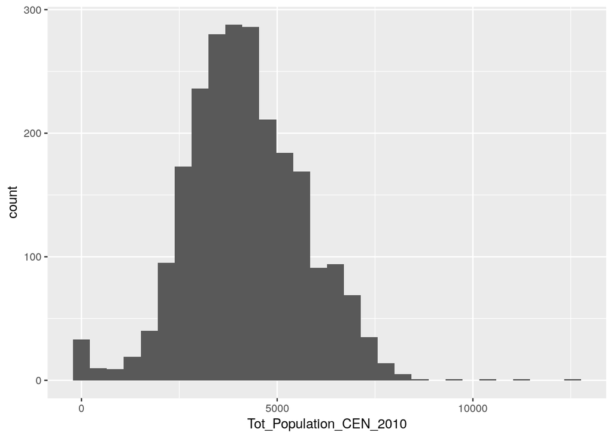

```r
# library(ggplot2)

# convert
## Relevel the cars by mpg
## this allows the plot to sort from most to least

# histogram of population count (each entity is a tract)
qplot(data=data_pdb_df_pk,Tot_Population_CEN_2010,geom="histogram")
```

```r
# p = ggplot(data_pdb_df_pk, aes(x=reorder(state_county_tract,-Tot_Population_CEN_2010), y=Tot_Population_CEN_2010)) +
#     geom_point(stat="identity")
```

### On Your Own: Request Tract Size Variable, Make scatterplot of Population by Tract Size

http://api.census.gov/data/2015/pdb/tract/variables/LAND_AREA.json

```r
# ggplot(data_pdb_df_pk, aes(x=(LAND_AREA),y=(Tot_Population_CEN_2010))) +
# geom_point()
#
#
# ggplot(data_pdb_df_pk, aes(x=log(LAND_AREA),y=log(Tot_Population_CEN_2010))) +
# geom_point()
```

## Summarize a Table

### Assume A Table is Our Desired Analysis

County Level Count of Males and Females, sorted in decreasing order by Total Population Count

```r
str(data_pdb_df_pk)

data_pdb_df_pk %>%
mutate(Num_Males_2010 = Tot_Population_CEN_2010 - Females_CEN_2010) %>%
group_by(State_name,County_name) %>%
summarise(Num_M_2010_Cou=sum(Num_Males_2010),
         Num_F_2010_Cou=sum(Females_CEN_2010),
          Num_All_2010_Cou=sum(Tot_Population_CEN_2010)
         ) %>%
arrange(desc(Num_All_2010_Cou))

tab_sex_county = data_pdb_df_pk %>%
mutate(Num_Males_2010 = Tot_Population_CEN_2010 - Females_CEN_2010) %>%
group_by(State_name,County_name) %>%
summarise(Num_M_2010_Cou=sum(Num_Males_2010),
         Num_F_2010_Cou=sum(Females_CEN_2010),
          Num_All_2010_Cou=sum(Tot_Population_CEN_2010)
         ) %>%
arrange(desc(Num_All_2010_Cou))
```

[output not shown]

#### Assertion Check: How Many Counties in California?

https://www.google.com/search?q=how+many+counties+in+california&ie=utf-8&oe=utf-8

## Fit a Regression Model

Regress Population Count on Land Area

```r
names(data_pdb_df_pk)
```

```
## [1] "County_name"             "State_name"
## [3] "Tot_Population_CEN_2010" "LAND_AREA"
## [5] "Females_CEN_2010"        "state_county_tract"
```

```r
data_pdb_df_pk %>%
head()
```

```
##          County_name State_name Tot_Population_CEN_2010 LAND_AREA
## 1 Los Angeles County California                    4731     0.442
## 2 Los Angeles County California                    3664     1.021
## 3 Los Angeles County California                    5990     0.251
## 4 Los Angeles County California                    3363     0.270
## 5 Los Angeles County California                    4199     0.996
## 6 Los Angeles County California                    3903     2.436
##   Females_CEN_2010 state_county_tract
## 1             2352      06_037_101110
## 2             1869      06_037_101122
## 3             2953      06_037_101210
## 4             1702      06_037_101220
## 5             2183      06_037_101300
## 6             1948      06_037_101400
```

```r
# intercept allowed to be estimated when land area is 0
lm(Tot_Population_CEN_2010 ~ LAND_AREA,data=data_pdb_df_pk) %>%
summary()
```

```
##
## Call:
## lm(formula = Tot_Population_CEN_2010 ~ LAND_AREA, data = data_pdb_df_pk)
##
## Residuals:
##     Min      1Q  Median      3Q     Max
## -4204.4  -995.8  -101.8   972.2  8395.5
##
## Coefficients:
##             Estimate Std. Error t value Pr(>|t|)
## (Intercept) 4204.400     31.065 135.343  < 2e-16 ***
## LAND_AREA    -11.069      2.349  -4.712  2.6e-06 ***
## ---
## Signif. codes:  0 '***' 0.001 '**' 0.01 '*' 0.05 '.' 0.1 ' ' 1
##
## Residual standard error: 1492 on 2344 degrees of freedom
## Multiple R-squared:  0.009382,   Adjusted R-squared:  0.00896
## F-statistic:  22.2 on 1 and 2344 DF,  p-value: 2.6e-06
```

```r
# force intercept to be 0
# 0 population when 0 land area
lm(Tot_Population_CEN_2010 ~ -1 + LAND_AREA, data=data_pdb_df_pk) %>%
summary()
```

```
##
## Call:
## lm(formula = Tot_Population_CEN_2010 ~ -1 + LAND_AREA, data = data_pdb_df_pk)
##
## Residuals:
##    Min     1Q Median     3Q    Max
## -11239   3176   4075   5116  12390
##
## Coefficients:
##           Estimate Std. Error t value Pr(>|t|)
## LAND_AREA   30.522      6.913   4.415 1.06e-05 ***
## ---
## Signif. codes:  0 '***' 0.001 '**' 0.01 '*' 0.05 '.' 0.1 ' ' 1
##
## Residual standard error: 4428 on 2345 degrees of freedom
## Multiple R-squared:  0.008243,   Adjusted R-squared:  0.00782
## F-statistic: 19.49 on 1 and 2345 DF,  p-value: 1.057e-05
```

```r
# log-outcome and log-predictor, estimate the intercept
lm(log(Tot_Population_CEN_2010 + 0.01) ~ 1 + log(LAND_AREA + 0.01), data=data_pdb_df_pk) %>%
summary()
```

```
##
## Call:
## lm(formula = log(Tot_Population_CEN_2010 + 0.01) ~ 1 + log(LAND_AREA +
##     0.01), data = data_pdb_df_pk)
##
## Residuals:
##      Min       1Q   Median       3Q      Max
## -12.9279  -0.1239   0.1322   0.3727   1.3463
##
## Coefficients:
##                       Estimate Std. Error t value Pr(>|t|)
## (Intercept)            8.15111    0.02829 288.133   <2e-16 ***
## log(LAND_AREA + 0.01) -0.03727    0.02150  -1.733   0.0832 .
## ---
## Signif. codes:  0 '***' 0.001 '**' 0.01 '*' 0.05 '.' 0.1 ' ' 1
##
## Residual standard error: 1.1 on 2344 degrees of freedom
## Multiple R-squared:  0.00128,    Adjusted R-squared:  0.0008541
## F-statistic: 3.005 on 1 and 2344 DF,  p-value: 0.08316
```

## Mental Exercise: Reflect on how you got to this “final” analysis stage. Compare the amount of code in ‘Analyze Step 4’ with Steps 1-3.

Answer in the jupyter markdown block below

# 0b. ORGANIZE!

Organization is a fundamental part of Transparency, hence step 0. Further, Organization is crucial during handoff migrations.

## Transfer your wrangled data to a new environment

Output: ‘data_pdb_df_pk’

### In .csv format (Universal), Output Table to Computer File

Note: your_output_dir = ‘/home/foo’ needs to represent your output directory

```r
getwd()
```

```r
# your_output_dir = 'Z:\\projects\\workshop_ccpr_stat\\workshop_data_workflow\\data_proc\\'

your_output_dir = '/home/jovyan/work/test/'

# ?write.csv

# write.csv(tab_sex_county,paste0(your_output_dir,'tab_sex_county.csv'))

# drop row number

write.csv(data_pdb_df_pk,paste0(your_output_dir,'data_pdb_df_pk.csv'),row.names=FALSE)
```

```r
# list.files('/home/jovyan/work/test/')
list.files(your_output_dir)
```

### In .dta format (Stata), Output Table to Computer File

```r
# library(haven)

# ?write_dta
# write_dta(data_pdb_df_pk, paste0(your_output_dir,'data_pdb_df_pk_haven.dta'))
# ?read_dta

library(foreign)
# ?read.dta

write.dta(data_pdb_df_pk,paste0(your_output_dir,'data_pdb_df_pk_foreign.dta'))
```

```r
list.files('/home/jovyan/work/test/')
```

## Transfer your software versions. What versions are you using!?

Archive your software versions!

`?sessionInfo()`

**type in the function yourself in the Code box below**

### Software Versions… big whoop… So What? How do I make use of this info?

```r
# library(devtools)
# devtools::install_version("tidyr", version = "0.3.1", repos = "http://cran.us.r-project.org")
```

### Bundle the packages, export, and then unbundle in another environment

Even easier than manually installing specific version 1-by-1

https://rstudio.github.io/packrat/

```r
library(packrat)

# ?packrat::bundle
packrat::bundle()

# ?packrat::unbundle
bundle_path = "/foo_path/foo.tar.gz"
packrat::unbundle(bundle=bundle_path)
```

## Transfer your Jupyter File (from tmpnb.org) to your personal computer

Download as a .ipynb file or an .r

# Appendix

## Resources

- Jupyter http://jupyter.org/
- Rstudio https://www.rstudio.com/
- The Elements of Data Analytic Style https://leanpub.com/datastyle
- Tidy Data http://www.jstatsoft.org/v59/i10
- Open Science Framework https://osf.io/

## [R] to Stata Interface

https://github.com/EconometricsBySimulation/RStata/wiki/Dictionary:-Stata-to-R

## Need a STATA copy?

http://www.ccpr.ucla.edu/CCPRWebsite/services/computing

## Need a STATA hint?

http://www.ats.ucla.edu/stat/stata/modules/

## Fit a regression model in Stata

### read in data

use “Z:\projects\workshop_ccpr_stat\workshop_data_workflow\data_proc\data_pdb_df_pk_foreign.dta”, clear

### estimate intercept

reg Tot_Population_CEN_2010 LAND_AREA

### force intercept to be 0

reg Tot_Population_CEN_2010 LAND_AREA, nocon

### log-outcome and log-predictor, estimate the intercept

generate log_Tot_Pop = log(Tot_Population_CEN_2010+0.01)  
generate log_Land_Area = log(LAND_AREA+0.01)

reg log_Tot_Pop log_Land_Area